# Joins & more Plotting Completed

## Joins and More Plotting

For more information on joins, see: http://geopandas.org/mergingdata.html  
For more information on plotting and styling, see: http://geopandas.org/mapping.html

#### This time, we will build on the census tract dataframes we worked with earlier and join them to a GeoDataFrame.

Start by importing pandas as pd, geopandas as gpd, matplotlib.pyplot as plt, and os

```python
import pandas as pd
import geopandas as gpd
import matplotlib.pyplot as plt
import os
```

#### Set your working directory using os to workshopdata/

*Type:*  
*>>> os.chdir('../../')*

In the next cell, *type:*  
*>>> os.getcwd()* to view your current directory.

```python
os.chdir('../../')
```

```python
os.getcwd()
```

```
'/home/jupyter-boaty3'
```

### Import your data.

Use gpd.read_file() to import the following as a variable named TahoeTracts: TahoeTracts.geojson file from the workshopdata folder.

Use pd.read_csv() to import the following as a variable named AllTracts: the All_Counties.csv you produced in the earlier exercise. Should be in your current working directory.

```python
TahoeTracts = gpd.read_file('workshopdata/TahoeTracts.geojson')
```

```python
AllTracts = pd.read_csv('workshopdata/All_Counties.csv')
```

#### View your new TahoeTracts geodataframe and your AllTracts dataframe in the next two cells:

```python
TahoeTracts
```

|  | OBJECTID | STATEFP | COUNTYFP | TRACTCE | AFFGEOID | GEOID | NAME | LSAD | ALAND | AWATER | ... | ShapeSTAre | ShapeSTLen | POP_2010 | POP_2011 | POP_2012 | POP_2013 | POP_2014 | POP_2015 | POP_2016 | geometry |
| --- | --- | --- | --- | --- | --- | --- | --- | --- | --- | --- | --- | --- | --- | --- | --- | --- | --- | --- | --- | --- | --- |
| 0 | 5 | 06 | 017 | 031600 | 1400000US06017031600 | 06017031600 | 316 | CT | 7926181 | 0 | ... | 7.910677e+06 | 12369.248497 | 4126 | 3715 | 4025 | 4026 | 4073 | 3918 | 3868 | POLYGON ((763537.9836551668 4315733.585538371,... |
| 1 | 7 | 06 | 017 | 030502 | 1400000US06017030502 | 06017030502 | 305.02 | CT | 17251475 | 36532 | ... | 1.729684e+07 | 26313.490214 | 2641 | 2767 | 2446 | 2296 | 2340 | 2408 | 2393 | POLYGON ((756107.5910784202 4312352.066995064,... |
| 2 | 8 | 06 | 017 | 030505 | 1400000US06017030505 | 06017030505 | 305.05 | CT | 148884104 | 451002 | ... | 1.494343e+08 | 64339.455834 | 2704 | 1941 | 2011 | 2102 | 2288 | 2555 | 2506 | POLYGON ((756288.66584861 4293154.567955514, 7... |
| 3 | 9 | 06 | 061 | 020107 | 1400000US06061020107 | 06061020107 | 201.07 | CT | 7179614 | 301151 | ... | 7.748818e+06 | 19336.115918 | 3510 | 2966 | 3240 | 3355 | 3111 | 3279 | 2974 | POLYGON ((756205.4678623071 4347378.82132867, ... |
| 4 | 10 | 06 | 061 | 022100 | 1400000US06061022100 | 06061022100 | 221 | CT | 59523104 | 610172 | ... | 6.015945e+07 | 38311.939639 | 961 | 775 | 964 | 915 | 975 | 695 | 712 | POLYGON ((737695.3421095964 4329943.931698944,... |
| 5 | 12 | 06 | 061 | 022300 | 1400000US06061022300 | 06061022300 | 223 | CT | 26970758 | 1445828 | ... | 2.846237e+07 | 29087.423600 | 709 | 774 | 792 | 817 | 738 | 657 | 465 | POLYGON ((742251.022959603 4326559.309656151, ... |
| 6 | 15 | 06 | 061 | 020105 | 1400000US06061020105 | 06061020105 | 201.05 | CT | 27538208 | 917608 | ... | 2.847750e+07 | 26365.178953 | 1352 | 1284 | 1313 | 1186 | 1183 | 1124 | 910 | POLYGON ((746500.9871599386 4345515.946135351,... |
| 7 | 16 | 06 | 017 | 030401 | 1400000US06017030401 | 06017030401 | 304.01 | CT | 4779638 | 541288 | ... | 5.295395e+06 | 12169.387676 | 3498 | 4117 | 3921 | 4204 | 4185 | 3874 | 3727 | POLYGON ((758052.428158245 4313674.241877396, ... |
| 8 | 17 | 06 | 017 | 032000 | 1400000US06017032000 | 06017032000 | 320 | CT | 185118854 | 16702898 | ... | 2.019676e+08 | 92774.712261 | 1015 | 666 | 681 | 628 | 676 | 667 | 793 | POLYGON ((741888.4049193002 4322404.514040146,... |
| 9 | 18 | 06 | 017 | 030402 | 1400000US06017030402 | 06017030402 | 304.02 | CT | 10996508 | 0 | ... | 1.097609e+07 | 18090.954392 | 3723 | 3406 | 3485 | 3450 | 3512 | 3495 | 3754 | POLYGON ((757858.6178901512 4308600.865612617,... |
| 10 | 19 | 06 | 017 | 030200 | 1400000US06017030200 | 06017030200 | 302 | CT | 9413520 | 1486408 | ... | 1.093229e+07 | 28157.660122 | 4773 | 4985 | 4866 | 4971 | 4774 | 5122 | 5085 | POLYGON ((758448.6902930085 4314160.021097424,... |
| 11 | 20 | 06 | 061 | 020104 | 1400000US06061020104 | 06061020104 | 201.04 | CT | 22784547 | 718832 | ... | 2.351870e+07 | 23358.896988 | 1288 | 1115 | 1221 | 1049 | 1140 | 1198 | 1025 | POLYGON ((743461.9177602548 4342225.382377071,... |
| 12 | 21 | 06 | 017 | 030504 | 1400000US06017030504 | 06017030504 | 305.04 | CT | 29841317 | 0 | ... | 2.991250e+07 | 34654.718856 | 2912 | 2606 | 2863 | 2737 | 2535 | 2517 | 2523 | POLYGON ((759783.1446733195 4307185.273145664,... |
| 13 | 22 | 06 | 017 | 030302 | 1400000US06017030302 | 06017030302 | 303.02 | CT | 3241412 | 0 | ... | 3.222709e+06 | 7149.954847 | 2867 | 2909 | 3025 | 2838 | 2654 | 2756 | 2783 | POLYGON ((760105.6257202309 4314143.543000136,... |
| 14 | 23 | 06 | 017 | 030301 | 1400000US06017030301 | 06017030301 | 303.01 | CT | 1134174 | 0 | ... | 1.140877e+06 | 4804.178212 | 2469 | 2726 | 2332 | 2004 | 2195 | 2184 | 2279 | POLYGON ((760950.4026811561 4312520.682067305,... |
| 15 | 24 | 06 | 061 | 020106 | 1400000US06061020106 | 06061020106 | 201.06 | CT | 22134813 | 359834 | ... | 2.252008e+07 | 25390.897387 | 1719 | 1546 | 1470 | 1722 | 1605 | 1708 | 1549 | POLYGON ((751975.3986586956 4349196.49102943, ... |
| 16 | 25 | 06 | 061 | 022200 | 1400000US06061022200 | 06061022200 | 222 | CT | 23421449 | 658426 | ... | 2.409829e+07 | 22166.321794 | 909 | 1031 | 1071 | 981 | 1080 | 973 | 720 | POLYGON ((740404.0822636615 4338448.106498918,... |
| 17 | 27 | 32 | 005 | 001800 | 1400000US32005001800 | 32005001800 | 18 | CT | 24384403 | 0 | ... | 2.446818e+07 | 25242.736724 | 2152 | 1621 | 1690 | 2005 | 2027 | 1970 | 2242 | POLYGON ((765223.2288777279 4317212.837094843,... |
| 18 | 28 | 32 | 031 | 003305 | 1400000US32031003305 | 32031003305 | 33.05 | CT | 1469101 | 0 | ... | 1.479779e+06 | 5721.492317 | 1247 | 1328 | 1203 | 1312 | 1367 | 1340 | 1323 | POLYGON ((761364.9718129067 4349296.307312997,... |
| 19 | 29 | 32 | 031 | 003307 | 1400000US32031003307 | 32031003307 | 33.07 | CT | 2162328 | 172816 | ... | 2.325449e+06 | 9127.199582 | 1231 | 908 | 944 | 1084 | 1208 | 1334 | 1364 | POLYGON ((762969.1181488186 4348909.760276634,... |
| 20 | 34 | 32 | 031 | 003308 | 1400000US32031003308 | 32031003308 | 33.08 | CT | 18644049 | 428699 | ... | 1.886664e+07 | 34970.534568 | 2333 | 1843 | 1905 | 2102 | 2059 | 2185 | 2132 | POLYGON ((758465.1412903005 4346425.449485622,... |
| 21 | 35 | 32 | 031 | 003309 | 1400000US32031003309 | 32031003309 | 33.09 | CT | 42170951 | 1893955 | ... | 4.408516e+07 | 45196.420659 | 2546 | 2761 | 2463 | 2504 | 2424 | 2558 | 2244 | POLYGON ((762546.4514184017 4350313.481245542,... |
| 22 | 36 | 32 | 005 | 001700 | 1400000US32005001700 | 32005001700 | 17 | CT | 16602399 | 607877 | ... | 1.721655e+07 | 22213.329012 | 1601 | 1622 | 1563 | 1722 | 1762 | 2009 | 1894 | POLYGON ((763458.5283682477 4319809.30606739, ... |
| 23 | 38 | 32 | 005 | 001600 | 1400000US32005001600 | 32005001600 | 16 | CT | 57708530 | 2026394 | ... | 5.975450e+07 | 46059.467058 | 1591 | 793 | 990 | 1006 | 1155 | 1173 | 1137 | POLYGON ((762784.7934791641 4333177.226866653,... |
| 24 | 40 | 32 | 031 | 003306 | 1400000US32031003306 | 32031003306 | 33.06 | CT | 1426175 | 148536 | ... | 1.565794e+06 | 7213.022986 | 1730 | 1507 | 1612 | 1652 | 1524 | 1556 | 1713 | POLYGON ((761063.3437625626 4349017.165558951,... |

25 rows × 21 columns

```python
AllTracts
```

|  | GEOID | Name of Area | Qualifying Name | State/U.S.-Abbreviation (USPS) | Summary Level | Geographic Component | File Identification | Logical Record Number | US | Region | ... | Median Household Income (In 2017 Inflation Adjusted Dollars) | Housing Units | Occupied Housing Units: | Occupied Housing Units: Owner Occupied | Occupied Housing Units: Renter Occupied | Population for Whom Poverty Status Is Determined: | Population for Whom Poverty Status Is Determined: Under 1.00 (Doing Poorly) | Population for Whom Poverty Status Is Determined: 1.00 to 1.99 (Struggling) | Population for Whom Poverty Status Is Determined: Under 2.00 (Poor or Struggling) | Population for Whom Poverty Status Is Determined: 2.00 and Over (Doing Ok) |
| --- | --- | --- | --- | --- | --- | --- | --- | --- | --- | --- | --- | --- | --- | --- | --- | --- | --- | --- | --- | --- | --- |
| 0 | 32005001000 | Census Tract 10, Douglas County, Nevada | Census Tract 10, Douglas County, Nevada | nv | 140 | 0 | ACSSF | 818 | NaN | NaN | ... | 67805.0 | 1139 | 1034 | 863 | 171 | 2520 | 125 | 249 | 374 | 2146 |
| 1 | 32005001100 | Census Tract 11, Douglas County, Nevada | Census Tract 11, Douglas County, Nevada | nv | 140 | 0 | ACSSF | 819 | NaN | NaN | ... | 54907.0 | 2223 | 2198 | 1124 | 1074 | 5589 | 492 | 1174 | 1666 | 3923 |
| 2 | 32005001200 | Census Tract 12, Douglas County, Nevada | Census Tract 12, Douglas County, Nevada | nv | 140 | 0 | ACSSF | 820 | NaN | NaN | ... | 48029.0 | 1409 | 1322 | 759 | 563 | 2889 | 371 | 441 | 812 | 2077 |
| 3 | 32005001300 | Census Tract 13, Douglas County, Nevada | Census Tract 13, Douglas County, Nevada | nv | 140 | 0 | ACSSF | 821 | NaN | NaN | ... | 73854.0 | 879 | 757 | 700 | 57 | 1725 | 175 | 236 | 411 | 1314 |
| 4 | 32005001400 | Census Tract 14, Douglas County, Nevada | Census Tract 14, Douglas County, Nevada | nv | 140 | 0 | ACSSF | 822 | NaN | NaN | ... | 54605.0 | 1624 | 1455 | 908 | 547 | 3085 | 389 | 316 | 705 | 2380 |
| 5 | 32005001500 | Census Tract 15, Douglas County, Nevada | Census Tract 15, Douglas County, Nevada | nv | 140 | 0 | ACSSF | 823 | NaN | NaN | ... | 47435.0 | 2730 | 2669 | 1382 | 1287 | 5885 | 818 | 1433 | 2251 | 3634 |
| 6 | 32005001600 | Census Tract 16, Douglas County, Nevada | Census Tract 16, Douglas County, Nevada | nv | 140 | 0 | ACSSF | 824 | NaN | NaN | ... | 81750.0 | 1727 | 635 | 499 | 136 | 1221 | 82 | 58 | 140 | 1081 |
| 7 | 32005001700 | Census Tract 17, Douglas County, Nevada | Census Tract 17, Douglas County, Nevada | nv | 140 | 0 | ACSSF | 825 | NaN | NaN | ... | 50655.0 | 1281 | 778 | 282 | 496 | 1730 | 169 | 337 | 506 | 1224 |
| 8 | 32005001800 | Census Tract 18, Douglas County, Nevada | Census Tract 18, Douglas County, Nevada | nv | 140 | 0 | ACSSF | 826 | NaN | NaN | ... | 58913.0 | 1807 | 1104 | 753 | 351 | 2303 | 188 | 422 | 610 | 1693 |
| 9 | 32005001900 | Census Tract 19, Douglas County, Nevada | Census Tract 19, Douglas County, Nevada | nv | 140 | 0 | ACSSF | 827 | NaN | NaN | ... | 135764.0 | 849 | 526 | 437 | 89 | 1322 | 35 | 138 | 173 | 1149 |
| 10 | 32005002000 | Census Tract 20, Douglas County, Nevada | Census Tract 20, Douglas County, Nevada | nv | 140 | 0 | ACSSF | 828 | NaN | NaN | ... | 57325.0 | 1350 | 1317 | 956 | 361 | 3367 | 460 | 631 | 1091 | 2276 |
| 11 | 32005002100 | Census Tract 21, Douglas County, Nevada | Census Tract 21, Douglas County, Nevada | nv | 140 | 0 | ACSSF | 829 | NaN | NaN | ... | 71653.0 | 869 | 869 | 628 | 241 | 2150 | 98 | 139 | 237 | 1913 |
| 12 | 32005002200 | Census Tract 22, Douglas County, Nevada | Census Tract 22, Douglas County, Nevada | nv | 140 | 0 | ACSSF | 830 | NaN | NaN | ... | 81441.0 | 2772 | 2688 | 2408 | 280 | 6379 | 287 | 691 | 978 | 5401 |
| 13 | 32005002300 | Census Tract 23, Douglas County, Nevada | Census Tract 23, Douglas County, Nevada | nv | 140 | 0 | ACSSF | 831 | NaN | NaN | ... | 87375.0 | 1637 | 1473 | 1257 | 216 | 3515 | 210 | 325 | 535 | 2980 |
| 14 | 32005002400 | Census Tract 24, Douglas County, Nevada | Census Tract 24, Douglas County, Nevada | nv | 140 | 0 | ACSSF | 832 | NaN | NaN | ... | 43021.0 | 763 | 687 | 503 | 184 | 1814 | 494 | 383 | 877 | 937 |
| 15 | 32005002500 | Census Tract 25, Douglas County, Nevada | Census Tract 25, Douglas County, Nevada | nv | 140 | 0 | ACSSF | 833 | NaN | NaN | ... | 46481.0 | 1004 | 864 | 684 | 180 | 1804 | 254 | 431 | 685 | 1119 |
| 16 | 32005990000 | Census Tract 9900, Douglas County, Nevada | Census Tract 9900, Douglas County, Nevada | nv | 140 | 0 | ACSSF | 834 | NaN | NaN | ... | NaN | 0 | 0 | 0 | 0 | 0 | 0 | 0 | 0 | 0 |
| 17 | 32031000101 | Census Tract 1.01, Washoe County, Nevada | Census Tract 1.01, Washoe County, Nevada | nv | 140 | 0 | ACSSF | 882 | NaN | NaN | ... | 27213.0 | 2582 | 2185 | 432 | 1753 | 3113 | 972 | 680 | 1652 | 1461 |
| 18 | 32031000102 | Census Tract 1.02, Washoe County, Nevada | Census Tract 1.02, Washoe County, Nevada | nv | 140 | 0 | ACSSF | 883 | NaN | NaN | ... | 18539.0 | 2186 | 1630 | 83 | 1547 | 2755 | 1168 | 862 | 2030 | 725 |
| 19 | 32031000201 | Census Tract 2.01, Washoe County, Nevada | Census Tract 2.01, Washoe County, Nevada | nv | 140 | 0 | ACSSF | 884 | NaN | NaN | ... | 27739.0 | 1383 | 1241 | 406 | 835 | 3263 | 1004 | 1128 | 2132 | 1131 |
| 20 | 32031000202 | Census Tract 2.02, Washoe County, Nevada | Census Tract 2.02, Washoe County, Nevada | nv | 140 | 0 | ACSSF | 885 | NaN | NaN | ... | 25607.0 | 1674 | 1521 | 65 | 1456 | 2922 | 858 | 883 | 1741 | 1181 |
| 21 | 32031000300 | Census Tract 3, Washoe County, Nevada | Census Tract 3, Washoe County, Nevada | nv | 140 | 0 | ACSSF | 886 | NaN | NaN | ... | 36361.0 | 2313 | 2255 | 549 | 1706 | 3596 | 480 | 961 | 1441 | 2155 |
| 22 | 32031000400 | Census Tract 4, Washoe County, Nevada | Census Tract 4, Washoe County, Nevada | nv | 140 | 0 | ACSSF | 887 | NaN | NaN | ... | 63836.0 | 2731 | 2581 | 1547 | 1034 | 5309 | 564 | 471 | 1035 | 4274 |
| 23 | 32031000700 | Census Tract 7, Washoe County, Nevada | Census Tract 7, Washoe County, Nevada | nv | 140 | 0 | ACSSF | 888 | NaN | NaN | ... | 35476.0 | 2910 | 2587 | 709 | 1878 | 5131 | 847 | 1615 | 2462 | 2669 |
| 24 | 32031000900 | Census Tract 9, Washoe County, Nevada | Census Tract 9, Washoe County, Nevada | nv | 140 | 0 | ACSSF | 889 | NaN | NaN | ... | 27420.0 | 2071 | 1761 | 236 | 1525 | 4590 | 1437 | 1869 | 3306 | 1284 |
| 25 | 32031001005 | Census Tract 10.05, Washoe County, Nevada | Census Tract 10.05, Washoe County, Nevada | nv | 140 | 0 | ACSSF | 890 | NaN | NaN | ... | 45878.0 | 1543 | 1401 | 663 | 738 | 2755 | 368 | 677 | 1045 | 1710 |
| 26 | 32031001008 | Census Tract 10.08, Washoe County, Nevada | Census Tract 10.08, Washoe County, Nevada | nv | 140 | 0 | ACSSF | 891 | NaN | NaN | ... | 27229.0 | 2186 | 1995 | 63 | 1932 | 4416 | 1293 | 1922 | 3215 | 1201 |
| 27 | 32031001009 | Census Tract 10.09, Washoe County, Nevada | Census Tract 10.09, Washoe County, Nevada | nv | 140 | 0 | ACSSF | 892 | NaN | NaN | ... | 31429.0 | 1652 | 1494 | 324 | 1170 | 2920 | 594 | 735 | 1329 | 1591 |
| 28 | 32031001010 | Census Tract 10.10, Washoe County, Nevada | Census Tract 10.10, Washoe County, Nevada | nv | 140 | 0 | ACSSF | 893 | NaN | NaN | ... | 93125.0 | 1279 | 1238 | 996 | 242 | 2858 | 145 | 328 | 473 | 2385 |
| 29 | 32031001011 | Census Tract 10.11, Washoe County, Nevada | Census Tract 10.11, Washoe County, Nevada | nv | 140 | 0 | ACSSF | 894 | NaN | NaN | ... | 125577.0 | 1462 | 1370 | 1254 | 116 | 3648 | 182 | 234 | 416 | 3232 |
| ... | ... | ... | ... | ... | ... | ... | ... | ... | ... | ... | ... | ... | ... | ... | ... | ... | ... | ... | ... | ... | ... |
| 227 | 6061021502 | Census Tract 215.02, Placer County, California | Census Tract 215.02, Placer County, California | ca | 140 | 0 | ACSSF | 7169 | NaN | NaN | ... | 85393.0 | 1559 | 1479 | 1124 | 355 | 3665 | 226 | 455 | 681 | 2984 |
| 228 | 6061021603 | Census Tract 216.03, Placer County, California | Census Tract 216.03, Placer County, California | ca | 140 | 0 | ACSSF | 7170 | NaN | NaN | ... | 37756.0 | 2096 | 1902 | 766 | 1136 | 4438 | 940 | 992 | 1932 | 2506 |
| 229 | 6061021604 | Census Tract 216.04, Placer County, California | Census Tract 216.04, Placer County, California | ca | 140 | 0 | ACSSF | 7171 | NaN | NaN | ... | 99943.0 | 1410 | 1287 | 1166 | 121 | 4166 | 532 | 383 | 915 | 3251 |
| 230 | 6061021801 | Census Tract 218.01, Placer County, California | Census Tract 218.01, Placer County, California | ca | 140 | 0 | ACSSF | 7172 | NaN | NaN | ... | 93036.0 | 1960 | 1867 | 1755 | 112 | 4909 | 339 | 530 | 869 | 4040 |
| 231 | 6061021802 | Census Tract 218.02, Placer County, California | Census Tract 218.02, Placer County, California | ca | 140 | 0 | ACSSF | 7173 | NaN | NaN | ... | 56088.0 | 2656 | 2429 | 1756 | 673 | 6068 | 733 | 1334 | 2067 | 4001 |
| 232 | 6061021901 | Census Tract 219.01, Placer County, California | Census Tract 219.01, Placer County, California | ca | 140 | 0 | ACSSF | 7174 | NaN | NaN | ... | 64205.0 | 1366 | 1230 | 868 | 362 | 2598 | 165 | 420 | 585 | 2013 |
| 233 | 6061021902 | Census Tract 219.02, Placer County, California | Census Tract 219.02, Placer County, California | ca | 140 | 0 | ACSSF | 7175 | NaN | NaN | ... | 78281.0 | 1964 | 1887 | 1760 | 127 | 4774 | 270 | 784 | 1054 | 3720 |
| 234 | 6061022002 | Census Tract 220.02, Placer County, California | Census Tract 220.02, Placer County, California | ca | 140 | 0 | ACSSF | 7176 | NaN | NaN | ... | 56307.0 | 3070 | 2758 | 1903 | 855 | 7322 | 1045 | 1543 | 2588 | 4734 |
| 235 | 6061022011 | Census Tract 220.11, Placer County, California | Census Tract 220.11, Placer County, California | ca | 140 | 0 | ACSSF | 7177 | NaN | NaN | ... | 97857.0 | 2980 | 676 | 455 | 221 | 1576 | 92 | 113 | 205 | 1371 |
| 236 | 6061022013 | Census Tract 220.13, Placer County, California | Census Tract 220.13, Placer County, California | ca | 140 | 0 | ACSSF | 7178 | NaN | NaN | ... | 61250.0 | 1564 | 1006 | 791 | 215 | 2372 | 333 | 297 | 630 | 1742 |
| 237 | 6061022014 | Census Tract 220.14, Placer County, California | Census Tract 220.14, Placer County, California | ca | 140 | 0 | ACSSF | 7179 | NaN | NaN | ... | 70268.0 | 3163 | 511 | 359 | 152 | 1101 | 68 | 136 | 204 | 897 |
| 238 | 6061022100 | Census Tract 221, Placer County, California | Census Tract 221, Placer County, California | ca | 140 | 0 | ACSSF | 7180 | NaN | NaN | ... | 80859.0 | 1413 | 293 | 249 | 44 | 613 | 24 | 82 | 106 | 507 |
| 239 | 6061022200 | Census Tract 222, Placer County, California | Census Tract 222, Placer County, California | ca | 140 | 0 | ACSSF | 7181 | NaN | NaN | ... | 73795.0 | 1329 | 293 | 205 | 88 | 756 | 96 | 89 | 185 | 571 |
| 240 | 6061022300 | Census Tract 223, Placer County, California | Census Tract 223, Placer County, California | ca | 140 | 0 | ACSSF | 7182 | NaN | NaN | ... | 60521.0 | 1554 | 199 | 186 | 13 | 372 | 89 | 18 | 107 | 265 |
| 241 | 6061022400 | Census Tract 224, Placer County, California | Census Tract 224, Placer County, California | ca | 140 | 0 | ACSSF | 7183 | NaN | NaN | ... | 105526.0 | 1804 | 1746 | 1049 | 697 | 4780 | 350 | 471 | 821 | 3959 |
| 242 | 6061022500 | Census Tract 225, Placer County, California | Census Tract 225, Placer County, California | ca | 140 | 0 | ACSSF | 7184 | NaN | NaN | ... | 158607.0 | 1869 | 1745 | 1605 | 140 | 5981 | 157 | 338 | 495 | 5486 |
| 243 | 6061022600 | Census Tract 226, Placer County, California | Census Tract 226, Placer County, California | ca | 140 | 0 | ACSSF | 7185 | NaN | NaN | ... | 73504.0 | 2013 | 1911 | 793 | 1118 | 5107 | 545 | 683 | 1228 | 3879 |
| 244 | 6061022800 | Census Tract 228, Placer County, California | Census Tract 228, Placer County, California | ca | 140 | 0 | ACSSF | 7186 | NaN | NaN | ... | 92431.0 | 1656 | 1585 | 944 | 641 | 4666 | 260 | 310 | 570 | 4096 |
| 245 | 6061022900 | Census Tract 229, Placer County, California | Census Tract 229, Placer County, California | ca | 140 | 0 | ACSSF | 7187 | NaN | NaN | ... | 79556.0 | 1706 | 1698 | 847 | 851 | 5124 | 385 | 487 | 872 | 4252 |
| 246 | 6061023000 | Census Tract 230, Placer County, California | Census Tract 230, Placer County, California | ca | 140 | 0 | ACSSF | 7188 | NaN | NaN | ... | 111103.0 | 999 | 968 | 807 | 161 | 3254 | 93 | 97 | 190 | 3064 |
| 247 | 6061023100 | Census Tract 231, Placer County, California | Census Tract 231, Placer County, California | ca | 140 | 0 | ACSSF | 7189 | NaN | NaN | ... | 129531.0 | 2771 | 2654 | 1998 | 656 | 8312 | 254 | 457 | 711 | 7601 |
| 248 | 6061023200 | Census Tract 232, Placer County, California | Census Tract 232, Placer County, California | ca | 140 | 0 | ACSSF | 7190 | NaN | NaN | ... | 97798.0 | 1753 | 1675 | 1356 | 319 | 5573 | 307 | 310 | 617 | 4956 |
| 249 | 6061023300 | Census Tract 233, Placer County, California | Census Tract 233, Placer County, California | ca | 140 | 0 | ACSSF | 7191 | NaN | NaN | ... | 96442.0 | 1604 | 1604 | 1293 | 311 | 5318 | 373 | 282 | 655 | 4663 |
| 250 | 6061023400 | Census Tract 234, Placer County, California | Census Tract 234, Placer County, California | ca | 140 | 0 | ACSSF | 7192 | NaN | NaN | ... | 82396.0 | 1662 | 1619 | 1210 | 409 | 5007 | 333 | 728 | 1061 | 3946 |
| 251 | 6061023500 | Census Tract 235, Placer County, California | Census Tract 235, Placer County, California | ca | 140 | 0 | ACSSF | 7193 | NaN | NaN | ... | 133080.0 | 1766 | 1732 | 1560 | 172 | 6044 | 184 | 136 | 320 | 5724 |
| 252 | 6061023600 | Census Tract 236, Placer County, California | Census Tract 236, Placer County, California | ca | 140 | 0 | ACSSF | 7194 | NaN | NaN | ... | 67179.0 | 2655 | 2568 | 2261 | 307 | 4136 | 132 | 454 | 586 | 3550 |
| 253 | 6061023700 | Census Tract 237, Placer County, California | Census Tract 237, Placer County, California | ca | 140 | 0 | ACSSF | 7195 | NaN | NaN | ... | 61121.0 | 2056 | 2014 | 1764 | 250 | 3416 | 183 | 392 | 575 | 2841 |
| 254 | 6061023800 | Census Tract 238, Placer County, California | Census Tract 238, Placer County, California | ca | 140 | 0 | ACSSF | 7196 | NaN | NaN | ... | 61111.0 | 1957 | 1836 | 1598 | 238 | 3146 | 276 | 282 | 558 | 2588 |
| 255 | 6061023900 | Census Tract 239, Placer County, California | Census Tract 239, Placer County, California | ca | 140 | 0 | ACSSF | 7197 | NaN | NaN | ... | 104946.0 | 1031 | 1021 | 827 | 194 | 3258 | 263 | 154 | 417 | 2841 |
| 256 | 6061990000 | Census Tract 9900, Placer County, California | Census Tract 9900, Placer County, California | ca | 140 | 0 | ACSSF | 7198 | NaN | NaN | ... | NaN | 0 | 0 | 0 | 0 | 0 | 0 | 0 | 0 | 0 |

257 rows × 104 columns

### We will now perform a table join and add the attributes from AllTracts to TahoeTracts. We will join on the 'GEOID' columns.

# But...

#### Look closely at the AllTracts GEOID column. Notice anything?

*type:*  
*>>> AllTracts.GEOID*

```python
AllTracts.GEOID
```

```
0      32005001000
1      32005001100
2      32005001200
3      32005001300
4      32005001400
          ...
252     6061023600
253     6061023700
254     6061023800
255     6061023900
256     6061990000
Name: GEOID, Length: 257, dtype: int64
```

### Arrgghh! Classic problem: leading zeros have been stripped. WHY?!?!?!

### Fix it! Reimport the All_Counites.csv file to the same variable, but this time we'll tell pandas the 'GEOID' column should be read as a string.

*Type:*  
*>>> AllTracts = pd.read_csv('All_Counties.csv', DTYPE = {"GEOID":str})

```python
AllTracts = pd.read_csv('workshopdata/All_Counties.csv', dtype={"GEOID":str})
```

Check the results by *Typing:* AllTracts.GEOID

```python
AllTracts.GEOID
```

```
0      32005001000
1      32005001100
2      32005001200
3      32005001300
4      32005001400
          ...
252    06061023600
253    06061023700
254    06061023800
255    06061023900
256    06061990000
Name: GEOID, Length: 257, dtype: object
```

Note: TahoeTracts only consists of the census tracts around Lake Tahoe and that there are 25 tracts, but AllTracts represents all the tracts within each county bordering the lake: 257 tracts in total.

*Type:*  
*>>> TahoeTracts = TahoeTracts.merge(AllTracts, on='GEOID')*

```python
TahoeTracts = TahoeTracts.merge(AllTracts, on = 'GEOID')
```

### Ya did it.

View the results by *typing:*  
*>>> TahoeTracts*

```python
TahoeTracts
```

|  | OBJECTID | STATEFP | COUNTYFP | TRACTCE | AFFGEOID | GEOID | NAME | LSAD | ALAND | AWATER | ... | Median Household Income (In 2017 Inflation Adjusted Dollars) | Housing Units | Occupied Housing Units: | Occupied Housing Units: Owner Occupied | Occupied Housing Units: Renter Occupied | Population for Whom Poverty Status Is Determined: | Population for Whom Poverty Status Is Determined: Under 1.00 (Doing Poorly) | Population for Whom Poverty Status Is Determined: 1.00 to 1.99 (Struggling) | Population for Whom Poverty Status Is Determined: Under 2.00 (Poor or Struggling) | Population for Whom Poverty Status Is Determined: 2.00 and Over (Doing Ok) |
| --- | --- | --- | --- | --- | --- | --- | --- | --- | --- | --- | --- | --- | --- | --- | --- | --- | --- | --- | --- | --- | --- |
| 0 | 5 | 06 | 017 | 031600 | 1400000US06017031600 | 06017031600 | 316 | CT | 7926181 | 0 | ... | 36014.0 | 3366 | 1318 | 234 | 1084 | 3017 | 731 | 889 | 1620 | 1397 |
| 1 | 7 | 06 | 017 | 030502 | 1400000US06017030502 | 06017030502 | 305.02 | CT | 17251475 | 36532 | ... | 89583.0 | 1889 | 1027 | 932 | 95 | 2624 | 152 | 295 | 447 | 2177 |
| 2 | 8 | 06 | 017 | 030505 | 1400000US06017030505 | 06017030505 | 305.05 | CT | 148884104 | 451002 | ... | 63194.0 | 2102 | 921 | 682 | 239 | 2336 | 129 | 320 | 449 | 1887 |
| 3 | 9 | 06 | 061 | 020107 | 1400000US06061020107 | 06061020107 | 201.07 | CT | 7179614 | 301151 | ... | 43793.0 | 1973 | 1026 | 468 | 558 | 2614 | 322 | 768 | 1090 | 1524 |
| 4 | 10 | 06 | 061 | 022100 | 1400000US06061022100 | 06061022100 | 221 | CT | 59523104 | 610172 | ... | 80859.0 | 1413 | 293 | 249 | 44 | 613 | 24 | 82 | 106 | 507 |
| 5 | 12 | 06 | 061 | 022300 | 1400000US06061022300 | 06061022300 | 223 | CT | 26970758 | 1445828 | ... | 60521.0 | 1554 | 199 | 186 | 13 | 372 | 89 | 18 | 107 | 265 |
| 6 | 15 | 06 | 061 | 020105 | 1400000US06061020105 | 06061020105 | 201.05 | CT | 27538208 | 917608 | ... | 63958.0 | 2019 | 486 | 361 | 125 | 965 | 195 | 45 | 240 | 725 |
| 7 | 16 | 06 | 017 | 030401 | 1400000US06017030401 | 06017030401 | 304.01 | CT | 4779638 | 541288 | ... | 56339.0 | 3730 | 1551 | 1115 | 436 | 3692 | 323 | 557 | 880 | 2812 |
| 8 | 17 | 06 | 017 | 032000 | 1400000US06017032000 | 06017032000 | 320 | CT | 185118854 | 16702898 | ... | 77917.0 | 2786 | 256 | 202 | 54 | 596 | 27 | 25 | 52 | 544 |
| 9 | 18 | 06 | 017 | 030402 | 1400000US06017030402 | 06017030402 | 304.02 | CT | 10996508 | 0 | ... | 37868.0 | 2862 | 1664 | 756 | 908 | 3919 | 743 | 952 | 1695 | 2224 |
| 10 | 19 | 06 | 017 | 030200 | 1400000US06017030200 | 06017030200 | 302 | CT | 9413520 | 1486408 | ... | 54071.0 | 3386 | 2055 | 946 | 1109 | 5103 | 519 | 1110 | 1629 | 3474 |
| 11 | 20 | 06 | 061 | 020104 | 1400000US06061020104 | 06061020104 | 201.04 | CT | 22784547 | 718832 | ... | 70392.0 | 2064 | 518 | 332 | 186 | 979 | 206 | 76 | 282 | 697 |
| 12 | 21 | 06 | 017 | 030504 | 1400000US06017030504 | 06017030504 | 305.04 | CT | 29841317 | 0 | ... | 70435.0 | 2144 | 926 | 692 | 234 | 2433 | 230 | 346 | 576 | 1857 |
| 13 | 22 | 06 | 017 | 030302 | 1400000US06017030302 | 06017030302 | 303.02 | CT | 3241412 | 0 | ... | 36782.0 | 2504 | 1207 | 478 | 729 | 2718 | 529 | 793 | 1322 | 1396 |
| 14 | 23 | 06 | 017 | 030301 | 1400000US06017030301 | 06017030301 | 303.01 | CT | 1134174 | 0 | ... | 48269.0 | 1852 | 1054 | 543 | 511 | 2874 | 479 | 841 | 1320 | 1554 |
| 15 | 24 | 06 | 061 | 020106 | 1400000US06061020106 | 06061020106 | 201.06 | CT | 22134813 | 359834 | ... | 57262.0 | 1956 | 562 | 360 | 202 | 1488 | 122 | 268 | 390 | 1098 |
| 16 | 25 | 06 | 061 | 022200 | 1400000US06061022200 | 06061022200 | 222 | CT | 23421449 | 658426 | ... | 73795.0 | 1329 | 293 | 205 | 88 | 756 | 96 | 89 | 185 | 571 |
| 17 | 27 | 32 | 005 | 001800 | 1400000US32005001800 | 32005001800 | 18 | CT | 24384403 | 0 | ... | 58913.0 | 1807 | 1104 | 753 | 351 | 2303 | 188 | 422 | 610 | 1693 |
| 18 | 28 | 32 | 031 | 003305 | 1400000US32031003305 | 32031003305 | 33.05 | CT | 1469101 | 0 | ... | 65417.0 | 835 | 510 | 335 | 175 | 1293 | 114 | 139 | 253 | 1040 |
| 19 | 29 | 32 | 031 | 003307 | 1400000US32031003307 | 32031003307 | 33.07 | CT | 2162328 | 172816 | ... | 74545.0 | 1229 | 506 | 311 | 195 | 1120 | 156 | 190 | 346 | 774 |
| 20 | 34 | 32 | 031 | 003308 | 1400000US32031003308 | 32031003308 | 33.08 | CT | 18644049 | 428699 | ... | 104313.0 | 1959 | 975 | 850 | 125 | 2073 | 119 | 95 | 214 | 1859 |
| 21 | 35 | 32 | 031 | 003309 | 1400000US32031003309 | 32031003309 | 33.09 | CT | 42170951 | 1893955 | ... | 93070.0 | 2621 | 1071 | 899 | 172 | 2287 | 106 | 156 | 262 | 2025 |
| 22 | 36 | 32 | 005 | 001700 | 1400000US32005001700 | 32005001700 | 17 | CT | 16602399 | 607877 | ... | 50655.0 | 1281 | 778 | 282 | 496 | 1730 | 169 | 337 | 506 | 1224 |
| 23 | 38 | 32 | 005 | 001600 | 1400000US32005001600 | 32005001600 | 16 | CT | 57708530 | 2026394 | ... | 81750.0 | 1727 | 635 | 499 | 136 | 1221 | 82 | 58 | 140 | 1081 |
| 24 | 40 | 32 | 031 | 003306 | 1400000US32031003306 | 32031003306 | 33.06 | CT | 1426175 | 148536 | ... | 66563.0 | 1350 | 691 | 337 | 354 | 1968 | 418 | 231 | 649 | 1319 |

25 rows × 124 columns

### Great! You've added over a hundred columns. This is the same as a "join" in ArcGIS.

#### Let's export this because we will use this file again later.

*Type:*  
*>>> TahoeTracts.to_file('TahoeTracts_geodata.geojson', driver = 'GeoJSON')*

```python
TahoeTracts.to_file('TahoeTracts_geodata.geojson', driver = 'GeoJSON')
```

## Now let's work on plotting.

Plot it! *Type:*  
*>>> TahoeTracts.plot()*

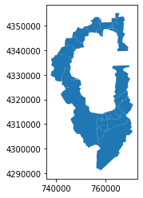

```python
TahoeTracts.plot()
```

### Now try making a choropleth

First, *Type:*  
*>>> list(TahoeTracts)* to list all of the column headers

```python
list(TahoeTracts)
```

```
['OBJECTID',
 'STATEFP',
 'COUNTYFP',
 'TRACTCE',
 'AFFGEOID',
 'GEOID',
 'NAME',
 'LSAD',
 'ALAND',
 'AWATER',
 'County_x',
 'ShapeSTAre',
 'ShapeSTLen',
 'POP_2010',
 'POP_2011',
 'POP_2012',
 'POP_2013',
 'POP_2014',
 'POP_2015',
 'POP_2016',
 'geometry',
 'Name of Area',
 'Qualifying Name',
 'State/U.S.-Abbreviation (USPS)',
 'Summary Level',
 'Geographic Component',
 'File Identification',
 'Logical Record Number',
 'US',
 'Region',
 'Division',
 'State (Census Code)',
 'State (FIPS)',
 'County_y',
 'County Subdivision (FIPS)',
 'Place (FIPS Code)',
 'Place (State FIPS + Place FIPS)',
 'Census Tract',
 'Block Group',
 'Consolidated City',
```

[output cut: 69 more lines]

```
 'Households: Family Households: Other Family: Male Householder, No Wife Present',
 'Households: Family Households: Other Family: Female Householder, No Husband Present',
 'Households: Nonfamily Households',
 'Households: Nonfamily Households: Male Householder',
 'Households: Nonfamily Households: Female Householder',
 'Median Household Income (In 2017 Inflation Adjusted Dollars)',
 'Housing Units',
 'Occupied Housing Units:',
 'Occupied Housing Units: Owner Occupied',
 'Occupied Housing Units: Renter Occupied',
 'Population for Whom Poverty Status Is Determined:',
 'Population for Whom Poverty Status Is Determined: Under 1.00 (Doing Poorly)',
 'Population for Whom Poverty Status Is Determined: 1.00 to 1.99 (Struggling)',
 'Population for Whom Poverty Status Is Determined: Under 2.00 (Poor or Struggling)',
 'Population for Whom Poverty Status Is Determined: 2.00 and Over (Doing Ok)']
```

#### Next,

*Type:*  
*>>> TahoeTracts.plot('a column name')*

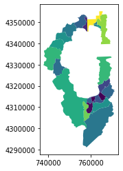

```python
TahoeTracts.plot('Median Household Income (In 2017 Inflation Adjusted Dollars)')
```

#### Add a legend

*Type:*  
*>>> TahoeTracts.plot('Median Household Income (In 2017 Inflation Adjusted Dollars)', legend=True)*

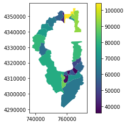

```python
TahoeTracts.plot('Median Household Income (In 2017 Inflation Adjusted Dollars)', legend = True)
```

#### Change the figure size

*Type:*  
*>>> TahoeTracts.plot('Median Household Income (In 2017 Inflation Adjusted Dollars)', legend=True, figsize = (8,8))*

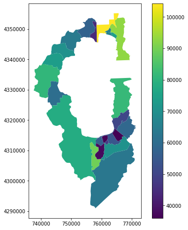

```python
TahoeTracts.plot('Median Household Income (In 2017 Inflation Adjusted Dollars)', legend = True, figsize = (8,8))
```

#### Next, modify the color scheme

*Type:*  
*>>>TahoeTracts.plot('Median Household Income (In 2017 Inflation Adjusted Dollars)', legend=True, figsize = (8,8), cmap='OrRd')*

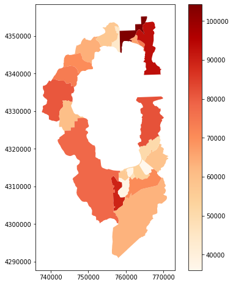

```python
TahoeTracts.plot('Median Household Income (In 2017 Inflation Adjusted Dollars)',
                 legend = True,
                 figsize = (8,8),
                 cmap='OrRd'
                )
```

#### You love this *beautiful* map! So Save it as an image!

Past your code form the previous cell into the cell below. Press enter to add a second line, then *Type:*  
*>>> plt.savefig('TahoeMHHI.png')*

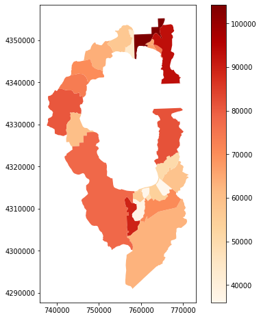

```python
TahoeTracts.plot('Median Household Income (In 2017 Inflation Adjusted Dollars)',
                 legend = True,
                 figsize = (8,8),
                 cmap='OrRd'
                )

plt.savefig('TahoeMHHI.png')
```

## Done! Open up yor data folder and double click on TahoeMHHI.png to view

#### Bonus! Want to add another layer?

Add a points of interest layer:

*Type:*  
*>>> POIs = gpd.read_file('workshopdata/Tahoe_POIs.geojson)*

```python
POIs = gpd.read_file('workshopdata/Tahoe_POIs.geojson')
```

#### Now, as before, use TahoeTracts.plot(), but you will make it a variable named 'basemap'

*In the next cell, first type:*  
*>>> basemap = TahoeTracts.plot()*

#### Then, plot the 'POIs' layer and pass 'ax = basemap' as the only arguement (that is, put it in the parentheses)

*In a new line in the same cell, type:*  
*>>> POIs.plot(ax = basemap)*

[figure not shown]

```python
basemap = TahoeTracts.plot()

POIs.plot(ax = basemap)
```

```python
#### Hey, what the heck?! I thought this was supposed to work.

## Time for you to troubleshoot. What do you think the problem is? How might you fix it?
```

```python
TahoeTracts.crs
```

```
{'init': 'epsg:26910'}
```

```python
POIs.crs
```

```
{'init': 'epsg:4326'}
```

```python
TahoeTracts = TahoeTracts.to_crs(epsg = 4326)
```

#### You have two layers displayed, but now let's sytle them

Past the above code into the next cell, but add styling parameters to TahoeTracts:

Modify 'basemap' adding *color='white', edgecolor='blue', figsize = (8,8)* into the TahoeTracts.plot() parentheses

for POIs.plot(), add *color = 'red'* into POIS.plot() parentheses

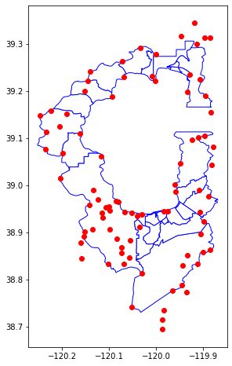

```python
basemap = TahoeTracts.plot(color = 'white',
                           edgecolor='blue',
                           figsize=(8,8))

POIs.plot(ax = basemap, color = 'red')
```